# Predicción de la calidad del aire de Madrid mediante modelos supervisados

## 2. Caracterización del clima de Madrid

El clima de la ciudad de Madrid según la clasificación climática de Köppen es clima templado con verano seco y caluroso (Csa).

A continuación se muestran los valores climatológicos medios para cada estación del año según los datos del periodo 2013-2018.

```r
# primavera (20/03 -20/06)
cat("Climatología en los meses de primavera:\n")
```

```
## Climatología en los meses de primavera:
```

```r
print(colMeans(datos[format(datos$fecha,"%m-%d")>='03-20'&format(datos$fecha,"%m-%d")<='06-20',c("prec","presMax","presMin","racha","tmax","tmed","tmin","velMedia")], na.rm = TRUE))
```

```
##       prec    presMax    presMin      racha       tmax       tmed
##   1.356160 940.749261 936.472653  10.059066  22.302974  16.690451
##       tmin   velMedia
##  11.075544   2.169695
```

```r
# verano (21/06 - 22/09)
cat("\nclimatología en los meses de verano:\n")
```

```
##
## climatología en los meses de verano:
```

```r
print(colMeans(datos[format(datos$fecha,"%m-%d")>='06-21'&format(datos$fecha,"%m-%d")<='09-22',c("prec","presMax","presMin","racha","tmax","tmed","tmin","velMedia")], na.rm = TRUE))
```

```
##        prec     presMax     presMin       racha        tmax        tmed
##   0.3027999 941.8917884 938.3083001   9.3538316  32.2228581  25.7723120
##        tmin    velMedia
##  19.3199273   1.8540635
```

```r
# otoño (23/09 - 20/12)
cat("\nClimatología en los meses de otoño:\n")
```

```
##
## Climatología en los meses de otoño:
```

```r
print(colMeans(datos[format(datos$fecha,"%m-%d")>='09-23'&format(datos$fecha,"%m-%d")<='12-20',c("prec","presMax","presMin","racha","tmax","tmed","tmin","velMedia")], na.rm = TRUE))
```

```
##       prec    presMax    presMin      racha       tmax       tmed
##   1.366122 944.524573 940.236750   7.446734  17.204950  13.069711
##       tmin   velMedia
##   8.931080   1.369560
```

```r
# invierno (21/12 - 19/03)
cat("\nClimatología en los meses de invierno:\n")
```

```
##
## Climatología en los meses de invierno:
```

```r
print(colMeans(datos[(format(datos$fecha,"%m-%d")>='12-21'&format(datos$fecha,"%m-%d")<='12-31') | (format(datos$fecha,"%m-%d")>='01-01' & format(datos$fecha,"%m-%d")<='03-19'),c("prec","presMax","presMin","racha","tmax","tmed","tmin","velMedia")], na.rm = TRUE))
```

```
##       prec    presMax    presMin      racha       tmax       tmed
##   1.473921 944.927345 939.634308   9.481624  11.882267   7.934427
##       tmin   velMedia
##   3.986189   1.996993
```

A continuación se muestra un gráfico temporal con los datos de temperatura y precipitaciones a lo largo del año 2018:

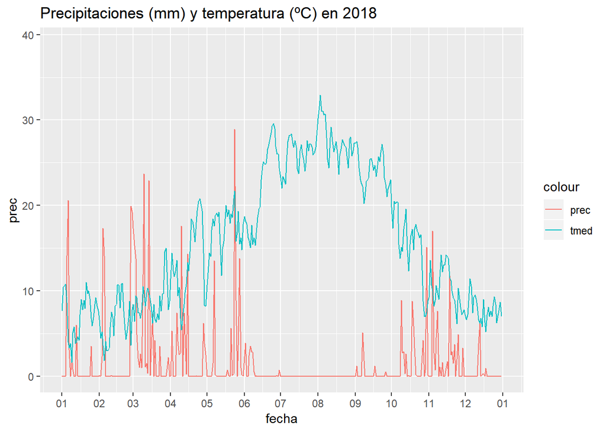

```r
# Gráficos
library(ggplot2)

# Precipitaciones y temperatura
ggplot(data = datos, aes(fecha, prec)) + geom_line(aes(y = prec, colour = "prec")) + geom_line(aes(y = tmed, colour = "tmed")) + scale_x_date(date_breaks = "1 month", date_labels = "%m", limits=as.Date(c('2018-01-01','2018-12-31'))) + ggtitle("Precipitaciones (mm) y temperatura (ºC) en 2018")
```

Como se puede observar en el gráfico, el clima de Madrid a lo largo del año se caracteriza por una sequia estival que se corresponde con las temperaturas más elevadas.

A continuación se muestra el nivel de lluvias acumulado (mm) durante los meses del año 2018:

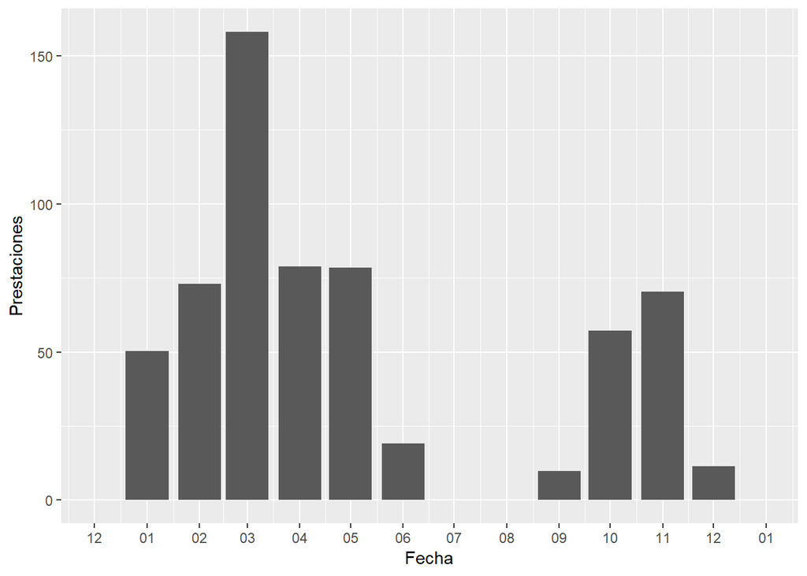

```r
# Precipitaciones acumulado
ggplot(data = clima, aes(x = as.Date(cut(clima$fecha, breaks = "month")), y = prec)) + stat_summary(fun.y = cumsum, geom = "bar") + scale_x_date(date_breaks = "1 month", date_labels = "%m", limits=as.Date(c('2017-12-01','2018-12-31'))) + xlab("Fecha") + ylab("Prestaciones")
```

Durante el año 2018, el mes de mayor acumulación de lluvias fue marzo seguido de abril y mayo.

## 3. Modelo de predicción de la calidad del aire de Madrid

Funciones genéricas de entrenamiento y predicción para los modelos MLP, LSTM y CNN. Además de funciones de evaluación y comparación de resultados para todos los modelos:

```r
entrenar_modelo <- function(tipo, modelo, batch_size, epochs) {

  if(typeof(X_train)=="list") {
    # X_train contiene varios predictores

    # Truncamos las observaciones de X_train e Y_train para coincidir con el batch_size
    num = batch_size*as.integer(nrow(X_train)/batch_size)

    # Convertimos el data frame X_train en una matriz
    X_train <- data.matrix(X_train[1:num,]) #Si X_train contiene varias columnas

    if (tipo == "lstm" | tipo == "cnn") {

      # Redimensionamos la matrix X_train
        dim(X_train) <- c(dim(X_train)[1],1,dim(X_train)[2])

    }

  } else {
    # X_train contiene un único predictor

    # Truncamos las observaciones de X_train e Y_train para coincidir con el batch_size
    num = batch_size*as.integer(length(X_train)/batch_size)

    # Convertimos el data frame X_train en una matriz
    X_train <- data.matrix(X_train[1:num]) #Si X_train es un Array

    if (tipo == "lstm" | tipo == "cnn") {

      # Redimensionamos la matrix X_train
      dim(X_train) <- c(dim(X_train)[1],1,dim(X_train)[2])

    }

  }

  # Entrenamos el modelo
  modelo %>% fit(X_train, Y_train[1:num], batch_size = batch_size, epochs = epochs, verbose = 1, shuffle = FALSE)

}
```

```r
predicciones_modelo <- function(tipo, modelo, batch_size) {

  if(typeof(X_test)=="list") {
    # X_test contiene varios predictores

    # Truncamos las observaciones de X_test e Y_test para coincidir con el batch_size
    num = as.integer(nrow(X_test)/batch_size)*batch_size

    # Convertimos el data frame X_train en una matriz
    X_test <- data.matrix(X_test[1:num,]) #Si X_test contiene varias columnas

    if (tipo == "lstm" | tipo == "cnn") {

      # Redimensionamos la matrix X_train
      dim(X_test) <- c(dim(X_test)[1],1,dim(X_test)[2])

    }

  } else {
    # X_test contiene un único predictor

    # Truncamos las observaciones de X_test e Y_test para coincidir con el batch_size
    num = as.integer(length(X_test)/batch_size)*batch_size

    # Convertimos el data frame X_test en una matriz
    X_test <- data.matrix(X_test[1:num]) #Si X_test es un Array

    if (tipo == "lstm" | tipo == "cnn") {

      # Redimensionamos la matrix X_test
      dim(X_test) <- c(dim(X_test)[1],1,dim(X_test)[2])

    }
  }

  # Usamos el modelo para realizar las predicciones
  Y_pred <- modelo %>% predict(X_test, batch_size = batch_size)

  return(Y_pred)

}
```

```r
evaluar_modelo <- function() {

  # Evaluamos el modelo calculando la raíz cuadrada del error cuadrático medio (RMSE)
  return(sqrt(mean((Y_pred - Y_test[1:length(Y_pred)])^2)))

}
```

```r
comparar_prediccion<-function(Y_test,Y_pred, titulo) {

  # Importamos la librería ggplot2
  library(ggplot2)

  # Creamos un data frame con los datos reales y las predicciones
  resultado <- cbind(Y_test[1:length(Y_pred)],Y_pred)
  resultado <- as.data.frame(resultado)
  colnames(resultado) <- c("Y_test","Y_pred")

  # Creamos un vector X con para el eje de abscisas
  X <- c(1:length(Y_pred))

  # Mostramos los datos reales y las predicciones con un gráfico de líneas
  p <- ggplot() + geom_line(data = resultado, aes(x=X, y=resultado$Y_test, colour = "Y_test"), size = 1) + geom_line(data = resultado, aes(x=X, y=resultado$Y_pred, colour = "Y_pred"), size = 1) + xlab("Tiempo") + ylab("Contaminación") + ggtitle(titulo)

  print(p)

}
```

### 3.1. Modelo basado en MLP (Multilayer perceptron)

```r
crear_modelo_mlp <- function(batch_size, n, units, activation) {

  # Importamos la librería keras para crear el modelo
  library(keras)

  # Destroys the current TF graph and creates a new one. Useful to avoid clutter from old models / layers.
  k_clear_session()

  # Creamos un modelo secuencial como una pila lineal de capas
  modelo <- keras_model_sequential()

  # Añadimos las capas al modelo
  modelo %>%
    layer_dense(units = units, batch_input_shape = c(batch_size, n), activation = activation) %>%
    layer_dense(units = units, activation = activation) %>%
    layer_dense(units = units, activation = activation) %>%
    layer_dense(units = 1)

  # Compilamos el modelo
  modelo %>% compile(loss = 'mean_squared_error', optimizer = 'adam')

  return(modelo)

}
```

```r
# Establecemos los hiperparámetros del modelo MLP
tipo = "mlp" # Modelo tipo MLP
cod_contaminante = 8 # Dióxido de nitrógeno
cod_estacion = 28079004 # Plaza de España
predictores = 3 # Como variables predictoras utilizamos las medidas de contaminación, las medidas climatológicas y el calendario laboral
pred_clima = FALSE # Uso de predicción del clima
activation = "relu"
n = switch(predictores,1,9,10) # n contiene el numero de predictores en cada observacion (n=1 si k=1, n=9 si k=2, n=10 si k=3)
batch_size = 7
units = 128
epochs = 10

cat("Predicción mediante modelo MLP.\n Contaminante:",cod_contaminante,"predictores:",predictores,"activation:",activation,"batch_size:",batch_size,"units:",units,"epochs:",epochs,"\n")
```

```
## Predicción mediante modelo MLP.
##  Contaminante: 8 predictores: 3 activation: relu batch_size: 7 units: 128 epochs: 10
```

```r
# Preparamos los datos de entrenamiento y prueba
returnList <- preparar_datos(cod_contaminante, cod_estacion, predictores, pred_clima)

X_train <- returnList$X_train
Y_train <- returnList$Y_train
X_test <- returnList$X_test
Y_test <- returnList$Y_test

# Creamos el modelo MLP
modelo <- crear_modelo_mlp(batch_size, n, units, activation)

# Entrenamos el modelo con X_train e Y_train (variables globales)
entrenar_modelo(tipo, modelo, batch_size, epochs)

# Predecimos los resultados para X_test (variable global)
Y_pred <- predicciones_modelo(tipo, modelo, batch_size)

# Evaluamos el modelo calculando el RMSE
rmse = evaluar_modelo()

cat("RMSE:",rmse,"\n")
```

```
## RMSE: 0.102814
```

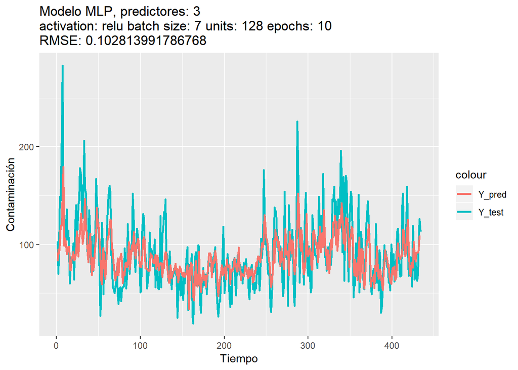

```r
# Revertimos la normalización de los datos de test
Y_pred <- (Y_pred * (returnList$maxYTest - returnList$minYTest)) + returnList$minYTest
Y_test <- (Y_test * (returnList$maxYTest - returnList$minYTest)) + returnList$minYTest

# Comparamos los datos reales y las predicciones con un gráfico de líneas
titulo = paste("Modelo MLP, predictores:",predictores,"\nactivation:",activation,"batch size:",batch_size,"units:",units,"epochs:",epochs,"\nRMSE:",rmse)
comparar_prediccion(Y_test,Y_pred,titulo)
```

### 3.2. Modelo basado en LSTM (Long Short-Term Memory)

```r
crear_modelo_lstm <- function(batch_size, n, units, activation) {

  # Importamos la librería keras para crear el modelo
  library(keras)

  # Destroys the current TF graph and creates a new one. Useful to avoid clutter from old models / layers.
  k_clear_session()

  # Creamos un modelo secuencial como una pila lineal de capas
  modelo <- keras_model_sequential()

  # Añadimos las capas al modelo
  modelo %>%
    layer_lstm(units = units, batch_input_shape = c(batch_size, 1, n),
               return_sequences = TRUE, stateful=TRUE, activation = activation) %>%
    layer_lstm(units = units, return_sequences = TRUE, stateful=TRUE, activation = activation) %>%
    layer_lstm(units = units, return_sequences = FALSE, stateful=TRUE, activation = activation) %>%
    layer_dense(units = 1)

  # Compilamos el modelo
  modelo %>% compile(loss = 'mean_squared_error', optimizer = 'RMSprop')

  return(modelo)

}
```

```r
# Establecemos los hiperparámetros del modelo LSTM
tipo = "lstm" # Modelo tipo LSTM
cod_contaminante = 8 # Dióxido de nitrógeno
cod_estacion = 28079004 # Plaza de España
predictores = 3 # Como variables predictoras utilizamos las medidas de contaminación, las medidas climatológicas y el calendario laboral
pred_clima = FALSE # Uso de predicción del clima
activation = "tanh"
n = switch(predictores,1,9,10) # n contiene el numero de predictores en cada observacion (n=1 si k=1, n=9 si k=2, n=10 si k=3)
batch_size = 30
units = 32
epochs = 10

cat("Predicción mediante modelo LSTM.\n Contaminante:",cod_contaminante,"predictores:",predictores,"activation:",activation,"batch_size:",batch_size,"units:",units,"epochs:",epochs,"\n")
```

```
## Predicción mediante modelo LSTM.
##  Contaminante: 8 predictores: 3 activation: tanh batch_size: 30 units: 32 epochs: 10
```

```r
# Preparamos los datos de entrenamiento y prueba
returnList <- preparar_datos(cod_contaminante, cod_estacion, predictores, pred_clima)

X_train <- returnList$X_train
Y_train <- returnList$Y_train
X_test <- returnList$X_test
Y_test <- returnList$Y_test

# Creamos el modelo LSTM
modelo <- crear_modelo_lstm(batch_size, n, units, activation)

# Entrenamos el modelo con X_train e Y_train (variables globales)
entrenar_modelo(tipo, modelo, batch_size, epochs)

# Predecimos los resultados para X_test (variable global)
Y_pred <- predicciones_modelo(tipo, modelo, batch_size)

# Evaluamos el modelo calculando el RMSE
rmse = evaluar_modelo()

cat("RMSE:",rmse,"\n")
```

```
## RMSE: 0.109267
```

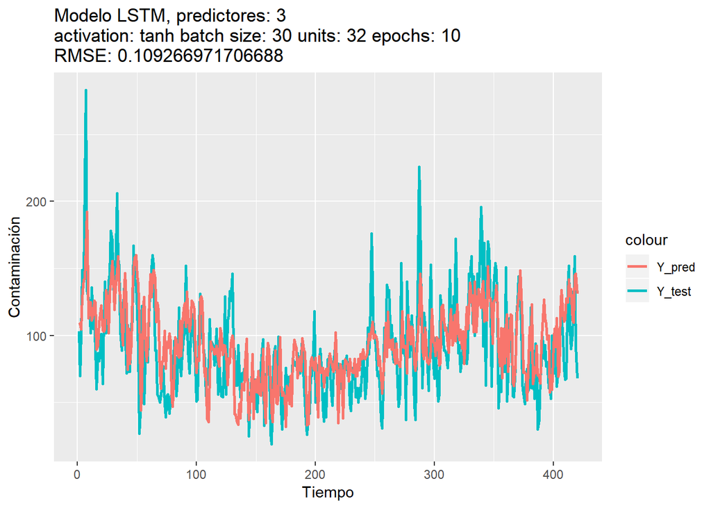

```r
# Revertimos la normalización de los datos de test
Y_pred <- (Y_pred * (returnList$maxYTest - returnList$minYTest)) + returnList$minYTest
Y_test <- (Y_test * (returnList$maxYTest - returnList$minYTest)) + returnList$minYTest

# Comparamos los datos reales y las predicciones con un gráfico de líneas
titulo = paste("Modelo LSTM, predictores:",predictores,"\nactivation:",activation,"batch size:",batch_size,"units:",units,"epochs:",epochs,"\nRMSE:",rmse)
comparar_prediccion(Y_test,Y_pred,titulo)
```

### 3.3. Modelo basado en CNN (Convolutional Neural Network)

```r
crear_modelo_cnn <- function(batch_size, n, filters, activation) {

  # Importamos la librería keras para crear el modelo
  library(keras)

  # Destroys the current TF graph and creates a new one. Useful to avoid clutter from old models / layers.
  k_clear_session()

  # Creamos un modelo secuencial como una pila lineal de capas
  modelo <- keras_model_sequential()

  # Añadimos las capas al modelo
  modelo %>%
    layer_conv_1d(filters = filters, kernel_size = 1, activation = activation, batch_input_shape = c(batch_size, 1, n)) %>%
    layer_conv_1d(filters = filters, kernel_size = 1, activation = activation) %>%
    layer_global_max_pooling_1d() %>%
    layer_dense(units = 1)

  # Compilamos el modelo
  modelo %>% compile(loss = 'mean_squared_error', optimizer = 'RMSprop')

  return(modelo)

}
```

```r
# Establecemos los hiperparámetros del modelo CNN
tipo = "cnn" # Modelo tipo LSTM
cod_contaminante = 8 # Dióxido de nitrógeno
cod_estacion = 28079004 # Plaza de España
predictores = 3 # Como variables predictoras utilizamos las medidas de contaminación, las medidas climatológicas y el calendario laboral
pred_clima = FALSE # Uso de predicción del clima
activation = "softmax"
n = switch(predictores,1,9,10) # n contiene el numero de predictores en cada observacion (n=1 si k=1, n=9 si k=2, n=10 si k=3)
batch_size = 1
filters = 128
epochs = 10

cat("Predicción mediante modelo CNN\n Contaminante:",cod_contaminante,"predictores:",predictores,"activation:",activation,"batch_size:",batch_size,"filters:",filters,"epochs:",epochs,"\n")
```

```
## Predicción mediante modelo CNN
##  Contaminante: 8 predictores: 3 activation: softmax batch_size: 1 filters: 128 epochs: 10
```

```r
# Preparamos los datos de entrenamiento y prueba
returnList <- preparar_datos(cod_contaminante, cod_estacion, predictores, pred_clima)

X_train <- returnList$X_train
Y_train <- returnList$Y_train
X_test <- returnList$X_test
Y_test <- returnList$Y_test

# Creamos el modelo CNN
modelo <- crear_modelo_cnn(batch_size, n, filters, activation)

# Entrenamos el modelo con X_train e Y_train (variables globales)
entrenar_modelo(tipo, modelo, batch_size, epochs)

# Predecimos los resultados para X_test (variable global)
Y_pred <- predicciones_modelo(tipo, modelo, batch_size)

# Evaluamos el modelo calculando el RMSE
rmse = evaluar_modelo()

cat("RMSE:",rmse,"\n")
```

```
## RMSE: 0.1112194
```

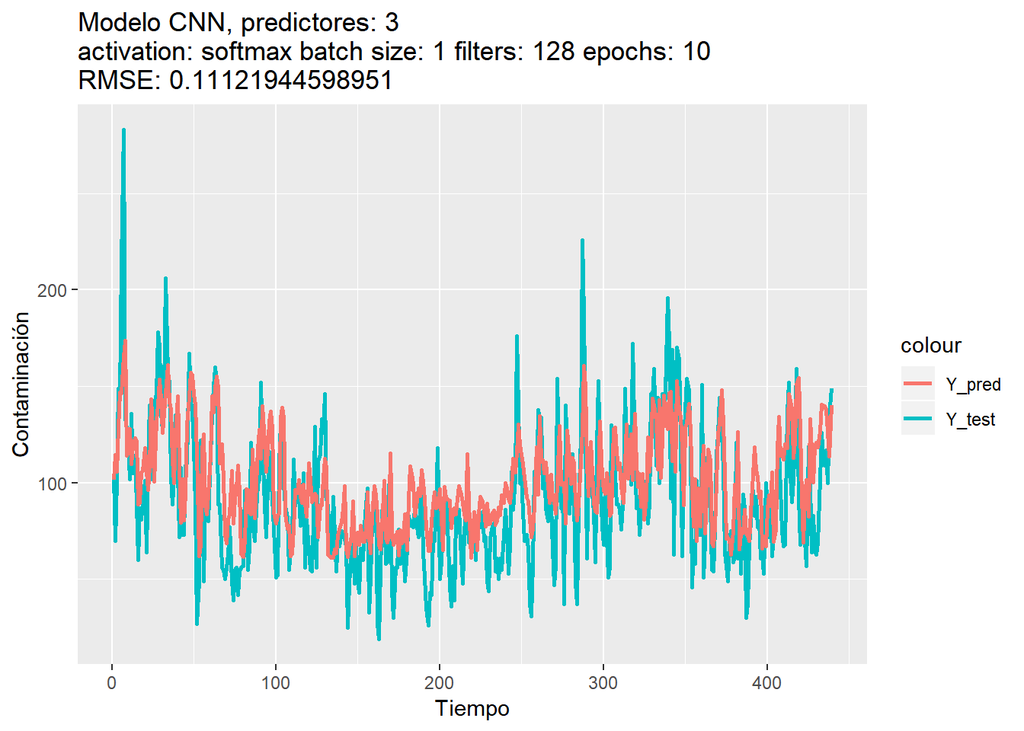

```r
# Revertimos la normalización de los datos de test
Y_pred <- (Y_pred * (returnList$maxYTest - returnList$minYTest)) + returnList$minYTest
Y_test <- (Y_test * (returnList$maxYTest - returnList$minYTest)) + returnList$minYTest

# Comparamos los datos reales y las predicciones con un gráfico de líneas
titulo = paste("Modelo CNN, predictores:",predictores,"\nactivation:",activation,"batch size:",batch_size,"filters:",filters,"epochs:",epochs,"\nRMSE:",rmse)
comparar_prediccion(Y_test,Y_pred,titulo)
```

### 3.4. Modelo basado en SVM (Support Vector Machines)

```r
# Cargamos la librería e1071
library(e1071)

# Establecemos los hiperparámetros del modelo SVM
cod_contaminante = 8 # Dióxido de nitrógeno
cod_estacion = 28079004 # Plaza de España
predictores = 3 # Como variables predictoras utilizamos las medidas de contaminación, las medidas climatológicas y el calendario laboral
pred_clima = FALSE # Uso de predicción del clima
type = "nu-regression"
kernel = "radial"

cat("Predicción mediante modelo SVM\n Contaminante:",cod_contaminante,"predictores:",predictores,"type:",type,"kernel:",kernel,"\n")
```

```
## Predicción mediante modelo SVM
##  Contaminante: 8 predictores: 3 type: nu-regression kernel: radial
```

```r
# Preparamos los datos de entrenamiento y prueba
returnList <- preparar_datos(cod_contaminante, cod_estacion, predictores, pred_clima)

X_train <- returnList$X_train
Y_train <- returnList$Y_train
X_test <- returnList$X_test
Y_test <- returnList$Y_test

# Creamos el modelo SVM con X_train e Y_train (variables globales)
modelo <- svm(x = X_train, y = Y_train, type = type, kernel = kernel)

# Predecimos los resultados para X_test (variable global)
Y_pred <- predict(modelo, X_test)

# Evaluamos el modelo calculando el RMSE
rmse = evaluar_modelo()

cat("RMSE:",rmse,"\n")
```

```
## RMSE: 0.09944565
```

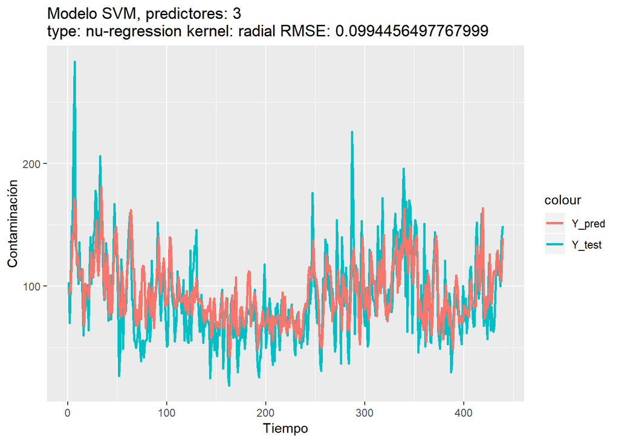

```r
# Revertimos la normalización de los datos de test
Y_pred <- (Y_pred * (returnList$maxYTest - returnList$minYTest)) + returnList$minYTest
Y_test <- (Y_test * (returnList$maxYTest - returnList$minYTest)) + returnList$minYTest

# Access just the obj values without names
Y_pred <- data.matrix(Y_pred)

# Comparamos los datos reales y las predicciones con un gráfico de líneas
titulo = paste("Modelo SVM, predictores:",predictores,"\ntype:",type,"kernel:",kernel,"RMSE:",rmse)
comparar_prediccion(Y_test,Y_pred,titulo)
```